# Movie Genres Data Analysis Project

# Introduction

We are going to focus highly on genre's. We need to know everything about Genre's.

Here are some things I want to look at:

## Research Questions:

1. Which genres are the most common (number of movies made)?
2. Which genres have high average budget and revenue?
3. Which genres have high average popularity?
4. Which genres have highest number of movies with a voting average >=8?

### Research Hypothesis:

1. The best movies according to vote average return high profit and revenue.
2. The best movies according to popularity return high profit and revenue.
3. Highly budgeted movies return high revenue and profit.
4. Highly budgeted movies have a high popularity.

```python
import pandas as pd

movies = pd.read_csv(r'D:\Data analytics\Projects\Pandas\imdb_movies.csv')
```

```python
pd.set_option('display.max.rows', 11000)
pd.set_option('display.max.columns', 22)
```

```python
movies.info()
```

```
<class 'pandas.core.frame.DataFrame'>
RangeIndex: 10866 entries, 0 to 10865
Data columns (total 21 columns):
 #   Column                Non-Null Count  Dtype
---  ------                --------------  -----
 0   id                    10866 non-null  int64
 1   imdb_id               10856 non-null  object
 2   popularity            10866 non-null  float64
 3   budget                10866 non-null  int64
 4   revenue               10866 non-null  int64
 5   original_title        10866 non-null  object
 6   cast                  10790 non-null  object
 7   homepage              2936 non-null   object
 8   director              10822 non-null  object
 9   tagline               8042 non-null   object
 10  keywords              9373 non-null   object
 11  overview              10862 non-null  object
 12  runtime               10866 non-null  int64
 13  genres                10843 non-null  object
 14  production_companies  9836 non-null   object
 15  release_date          10866 non-null  object
 16  vote_count            10866 non-null  int64
 17  vote_average          10866 non-null  float64
 18  release_year          10866 non-null  int64
 19  budget_adj            10866 non-null  float64
 20  revenue_adj           10866 non-null  float64
dtypes: float64(4), int64(6), object(11)
memory usage: 1.7+ MB
```

```python
movies.head()
```

|  | id | imdb_id | popularity | budget | revenue | original_title | cast | homepage | director | tagline | keywords | overview | runtime | genres | production_companies | release_date | vote_count | vote_average | release_year | budget_adj | revenue_adj |
| --- | --- | --- | --- | --- | --- | --- | --- | --- | --- | --- | --- | --- | --- | --- | --- | --- | --- | --- | --- | --- | --- |
| 0 | 135397 | tt0369610 | 32.985763 | 150000000 | 1513528810 | Jurassic World | Chris Pratt\|Bryce Dallas Howard\|Irrfan Khan\|Vi... | http://www.jurassicworld.com/ | Colin Trevorrow | The park is open. | monster\|dna\|tyrannosaurus rex\|velociraptor\|island | Twenty-two years after the events of Jurassic ... | 124 | Action\|Adventure\|Science Fiction\|Thriller | Universal Studios\|Amblin Entertainment\|Legenda... | 6/9/15 | 5562 | 6.500000 | 2015 | 137999939.280026 | 1392445892.523800 |
| 1 | 76341 | tt1392190 | 28.419936 | 150000000 | 378436354 | Mad Max: Fury Road | Tom Hardy\|Charlize Theron\|Hugh Keays-Byrne\|Nic... | http://www.madmaxmovie.com/ | George Miller | What a Lovely Day. | future\|chase\|post-apocalyptic\|dystopia\|australia | An apocalyptic story set in the furthest reach... | 120 | Action\|Adventure\|Science Fiction\|Thriller | Village Roadshow Pictures\|Kennedy Miller Produ... | 5/13/15 | 6185 | 7.100000 | 2015 | 137999939.280026 | 348161292.489031 |
| 2 | 262500 | tt2908446 | 13.112507 | 110000000 | 295238201 | Insurgent | Shailene Woodley\|Theo James\|Kate Winslet\|Ansel... | http://www.thedivergentseries.movie/#insurgent | Robert Schwentke | One Choice Can Destroy You | based on novel\|revolution\|dystopia\|sequel\|dyst... | Beatrice Prior must confront her inner demons ... | 119 | Adventure\|Science Fiction\|Thriller | Summit Entertainment\|Mandeville Films\|Red Wago... | 3/18/15 | 2480 | 6.300000 | 2015 | 101199955.472019 | 271619025.407628 |
| 3 | 140607 | tt2488496 | 11.173104 | 200000000 | 2068178225 | Star Wars: The Force Awakens | Harrison Ford\|Mark Hamill\|Carrie Fisher\|Adam D... | http://www.starwars.com/films/star-wars-episod... | J.J. Abrams | Every generation has a story. | android\|spaceship\|jedi\|space opera\|3d | Thirty years after defeating the Galactic Empi... | 136 | Action\|Adventure\|Science Fiction\|Fantasy | Lucasfilm\|Truenorth Productions\|Bad Robot | 12/15/15 | 5292 | 7.500000 | 2015 | 183999919.040035 | 1902723129.801820 |
| 4 | 168259 | tt2820852 | 9.335014 | 190000000 | 1506249360 | Furious 7 | Vin Diesel\|Paul Walker\|Jason Statham\|Michelle ... | http://www.furious7.com/ | James Wan | Vengeance Hits Home | car race\|speed\|revenge\|suspense\|car | Deckard Shaw seeks revenge against Dominic Tor... | 137 | Action\|Crime\|Thriller | Universal Pictures\|Original Film\|Media Rights ... | 4/1/15 | 2947 | 7.300000 | 2015 | 174799923.088033 | 1385748801.470520 |

```python
#Check for duplicates

movies[movies.duplicated()]
```

|  | id | imdb_id | popularity | budget | revenue | original_title | cast | homepage | director | tagline | keywords | overview | runtime | genres | production_companies | release_date | vote_count | vote_average | release_year | budget_adj | revenue_adj |
| --- | --- | --- | --- | --- | --- | --- | --- | --- | --- | --- | --- | --- | --- | --- | --- | --- | --- | --- | --- | --- | --- |
| 2090 | 42194 | tt0411951 | 0.596430 | 30000000 | 967000 | TEKKEN | Jon Foo\|Kelly Overton\|Cary-Hiroyuki Tagawa\|Ian... | NaN | Dwight H. Little | Survival is no game | martial arts\|dystopia\|based on video game\|mart... | In the year of 2039, after World Wars destroy ... | 92 | Crime\|Drama\|Action\|Thriller\|Science Fiction | Namco\|Light Song Films | 3/20/10 | 110 | 5.000000 | 2010 | 30000000.000000 | 967000.000000 |

```python
#Removing duplicates

movies.drop_duplicates(inplace = True)
```

```python
movies[movies.duplicated()]
```

|  | id | imdb_id | popularity | budget | revenue | original_title | cast | homepage | director | tagline | keywords | overview | runtime | genres | production_companies | release_date | vote_count | vote_average | release_year | budget_adj | revenue_adj |
| --- | --- | --- | --- | --- | --- | --- | --- | --- | --- | --- | --- | --- | --- | --- | --- | --- | --- | --- | --- | --- | --- |

```python
movies.dropna(subset = ['genres'], inplace = True)
```

```python
movies.head()
```

|  | id | imdb_id | popularity | budget | revenue | original_title | cast | homepage | director | tagline | keywords | overview | runtime | genres | production_companies | release_date | vote_count | vote_average | release_year | budget_adj | revenue_adj |
| --- | --- | --- | --- | --- | --- | --- | --- | --- | --- | --- | --- | --- | --- | --- | --- | --- | --- | --- | --- | --- | --- |
| 0 | 135397 | tt0369610 | 32.985763 | 150000000 | 1513528810 | Jurassic World | Chris Pratt\|Bryce Dallas Howard\|Irrfan Khan\|Vi... | http://www.jurassicworld.com/ | Colin Trevorrow | The park is open. | monster\|dna\|tyrannosaurus rex\|velociraptor\|island | Twenty-two years after the events of Jurassic ... | 124 | Action\|Adventure\|Science Fiction\|Thriller | Universal Studios\|Amblin Entertainment\|Legenda... | 6/9/15 | 5562 | 6.500000 | 2015 | 137999939.280026 | 1392445892.523800 |
| 1 | 76341 | tt1392190 | 28.419936 | 150000000 | 378436354 | Mad Max: Fury Road | Tom Hardy\|Charlize Theron\|Hugh Keays-Byrne\|Nic... | http://www.madmaxmovie.com/ | George Miller | What a Lovely Day. | future\|chase\|post-apocalyptic\|dystopia\|australia | An apocalyptic story set in the furthest reach... | 120 | Action\|Adventure\|Science Fiction\|Thriller | Village Roadshow Pictures\|Kennedy Miller Produ... | 5/13/15 | 6185 | 7.100000 | 2015 | 137999939.280026 | 348161292.489031 |
| 2 | 262500 | tt2908446 | 13.112507 | 110000000 | 295238201 | Insurgent | Shailene Woodley\|Theo James\|Kate Winslet\|Ansel... | http://www.thedivergentseries.movie/#insurgent | Robert Schwentke | One Choice Can Destroy You | based on novel\|revolution\|dystopia\|sequel\|dyst... | Beatrice Prior must confront her inner demons ... | 119 | Adventure\|Science Fiction\|Thriller | Summit Entertainment\|Mandeville Films\|Red Wago... | 3/18/15 | 2480 | 6.300000 | 2015 | 101199955.472019 | 271619025.407628 |
| 3 | 140607 | tt2488496 | 11.173104 | 200000000 | 2068178225 | Star Wars: The Force Awakens | Harrison Ford\|Mark Hamill\|Carrie Fisher\|Adam D... | http://www.starwars.com/films/star-wars-episod... | J.J. Abrams | Every generation has a story. | android\|spaceship\|jedi\|space opera\|3d | Thirty years after defeating the Galactic Empi... | 136 | Action\|Adventure\|Science Fiction\|Fantasy | Lucasfilm\|Truenorth Productions\|Bad Robot | 12/15/15 | 5292 | 7.500000 | 2015 | 183999919.040035 | 1902723129.801820 |
| 4 | 168259 | tt2820852 | 9.335014 | 190000000 | 1506249360 | Furious 7 | Vin Diesel\|Paul Walker\|Jason Statham\|Michelle ... | http://www.furious7.com/ | James Wan | Vengeance Hits Home | car race\|speed\|revenge\|suspense\|car | Deckard Shaw seeks revenge against Dominic Tor... | 137 | Action\|Crime\|Thriller | Universal Pictures\|Original Film\|Media Rights ... | 4/1/15 | 2947 | 7.300000 | 2015 | 174799923.088033 | 1385748801.470520 |

```python
movies['profit'] = movies['revenue'] - movies['budget']
```

```python
movies.head()
```

|  | id | imdb_id | popularity | budget | revenue | original_title | cast | homepage | director | tagline | keywords | overview | runtime | genres | production_companies | release_date | vote_count | vote_average | release_year | budget_adj | revenue_adj | profit |
| --- | --- | --- | --- | --- | --- | --- | --- | --- | --- | --- | --- | --- | --- | --- | --- | --- | --- | --- | --- | --- | --- | --- |
| 0 | 135397 | tt0369610 | 32.985763 | 150000000 | 1513528810 | Jurassic World | Chris Pratt\|Bryce Dallas Howard\|Irrfan Khan\|Vi... | http://www.jurassicworld.com/ | Colin Trevorrow | The park is open. | monster\|dna\|tyrannosaurus rex\|velociraptor\|island | Twenty-two years after the events of Jurassic ... | 124 | Action\|Adventure\|Science Fiction\|Thriller | Universal Studios\|Amblin Entertainment\|Legenda... | 6/9/15 | 5562 | 6.500000 | 2015 | 137999939.280026 | 1392445892.523800 | 1363528810 |
| 1 | 76341 | tt1392190 | 28.419936 | 150000000 | 378436354 | Mad Max: Fury Road | Tom Hardy\|Charlize Theron\|Hugh Keays-Byrne\|Nic... | http://www.madmaxmovie.com/ | George Miller | What a Lovely Day. | future\|chase\|post-apocalyptic\|dystopia\|australia | An apocalyptic story set in the furthest reach... | 120 | Action\|Adventure\|Science Fiction\|Thriller | Village Roadshow Pictures\|Kennedy Miller Produ... | 5/13/15 | 6185 | 7.100000 | 2015 | 137999939.280026 | 348161292.489031 | 228436354 |
| 2 | 262500 | tt2908446 | 13.112507 | 110000000 | 295238201 | Insurgent | Shailene Woodley\|Theo James\|Kate Winslet\|Ansel... | http://www.thedivergentseries.movie/#insurgent | Robert Schwentke | One Choice Can Destroy You | based on novel\|revolution\|dystopia\|sequel\|dyst... | Beatrice Prior must confront her inner demons ... | 119 | Adventure\|Science Fiction\|Thriller | Summit Entertainment\|Mandeville Films\|Red Wago... | 3/18/15 | 2480 | 6.300000 | 2015 | 101199955.472019 | 271619025.407628 | 185238201 |
| 3 | 140607 | tt2488496 | 11.173104 | 200000000 | 2068178225 | Star Wars: The Force Awakens | Harrison Ford\|Mark Hamill\|Carrie Fisher\|Adam D... | http://www.starwars.com/films/star-wars-episod... | J.J. Abrams | Every generation has a story. | android\|spaceship\|jedi\|space opera\|3d | Thirty years after defeating the Galactic Empi... | 136 | Action\|Adventure\|Science Fiction\|Fantasy | Lucasfilm\|Truenorth Productions\|Bad Robot | 12/15/15 | 5292 | 7.500000 | 2015 | 183999919.040035 | 1902723129.801820 | 1868178225 |
| 4 | 168259 | tt2820852 | 9.335014 | 190000000 | 1506249360 | Furious 7 | Vin Diesel\|Paul Walker\|Jason Statham\|Michelle ... | http://www.furious7.com/ | James Wan | Vengeance Hits Home | car race\|speed\|revenge\|suspense\|car | Deckard Shaw seeks revenge against Dominic Tor... | 137 | Action\|Crime\|Thriller | Universal Pictures\|Original Film\|Media Rights ... | 4/1/15 | 2947 | 7.300000 | 2015 | 174799923.088033 | 1385748801.470520 | 1316249360 |

```python
movies_genre = movies[['popularity', 'budget', 'revenue', 'original_title', 'runtime', 'genres', 'release_year', 'vote_count', 'vote_average', 'profit']]
```

```python
movies_genre.head()
```

|  | popularity | budget | revenue | original_title | runtime | genres | release_year | vote_count | vote_average | profit |
| --- | --- | --- | --- | --- | --- | --- | --- | --- | --- | --- |
| 0 | 32.985763 | 150000000 | 1513528810 | Jurassic World | 124 | Action\|Adventure\|Science Fiction\|Thriller | 2015 | 5562 | 6.500000 | 1363528810 |
| 1 | 28.419936 | 150000000 | 378436354 | Mad Max: Fury Road | 120 | Action\|Adventure\|Science Fiction\|Thriller | 2015 | 6185 | 7.100000 | 228436354 |
| 2 | 13.112507 | 110000000 | 295238201 | Insurgent | 119 | Adventure\|Science Fiction\|Thriller | 2015 | 2480 | 6.300000 | 185238201 |
| 3 | 11.173104 | 200000000 | 2068178225 | Star Wars: The Force Awakens | 136 | Action\|Adventure\|Science Fiction\|Fantasy | 2015 | 5292 | 7.500000 | 1868178225 |
| 4 | 9.335014 | 190000000 | 1506249360 | Furious 7 | 137 | Action\|Crime\|Thriller | 2015 | 2947 | 7.300000 | 1316249360 |

```python
from pandas import Series, DataFrame
```

```python
split = movies_genre['genres'].str.split('|').apply(Series,1).stack()
split.index = split.index.droplevel(-1)
split.name = 'genres_split'
del movies_genre['genres']
movies_genre = movies_genre.join(split)
```

```python
movies_genre
```

|  | popularity | budget | revenue | original_title | runtime | release_year | vote_count | vote_average | profit | genres_split |
| --- | --- | --- | --- | --- | --- | --- | --- | --- | --- | --- |
| 0 | 32.985763 | 150000000 | 1513528810 | Jurassic World | 124 | 2015 | 5562 | 6.500000 | 1363528810 | Action |
| 0 | 32.985763 | 150000000 | 1513528810 | Jurassic World | 124 | 2015 | 5562 | 6.500000 | 1363528810 | Adventure |
| 0 | 32.985763 | 150000000 | 1513528810 | Jurassic World | 124 | 2015 | 5562 | 6.500000 | 1363528810 | Science Fiction |
| 0 | 32.985763 | 150000000 | 1513528810 | Jurassic World | 124 | 2015 | 5562 | 6.500000 | 1363528810 | Thriller |
| 1 | 28.419936 | 150000000 | 378436354 | Mad Max: Fury Road | 120 | 2015 | 6185 | 7.100000 | 228436354 | Action |
| ... | ... | ... | ... | ... | ... | ... | ... | ... | ... | ... |
| 10863 | 0.065141 | 0 | 0 | Beregis Avtomobilya | 94 | 1966 | 11 | 6.500000 | 0 | Mystery |
| 10863 | 0.065141 | 0 | 0 | Beregis Avtomobilya | 94 | 1966 | 11 | 6.500000 | 0 | Comedy |
| 10864 | 0.064317 | 0 | 0 | What's Up, Tiger Lily? | 80 | 1966 | 22 | 5.400000 | 0 | Action |
| 10864 | 0.064317 | 0 | 0 | What's Up, Tiger Lily? | 80 | 1966 | 22 | 5.400000 | 0 | Comedy |
| 10865 | 0.035919 | 19000 | 0 | Manos: The Hands of Fate | 74 | 1966 | 15 | 1.500000 | -19000 | Horror |

26955 rows × 10 columns

We no longer have the genre column but now we have te genressplit column

1. Which genres are the most common (number of movies made)?

```python
genres_count = pd.DataFrame(movies_genre.groupby('genres_split').original_title.nunique()).sort_values('original_title',ascending = True)
```

```python
genres_count
```

| genres_split | original_title |
| --- | --- |
| Western | 163 |
| TV Movie | 167 |
| Foreign | 188 |
| War | 269 |
| History | 331 |
| Music | 403 |
| Documentary | 520 |
| Animation | 697 |
| Mystery | 796 |
| Fantasy | 899 |
| Science Fiction | 1207 |
| Family | 1211 |
| Crime | 1337 |
| Adventure | 1442 |
| Horror | 1580 |
| Romance | 1686 |
| Action | 2339 |
| Thriller | 2841 |
| Comedy | 3750 |
| Drama | 4672 |

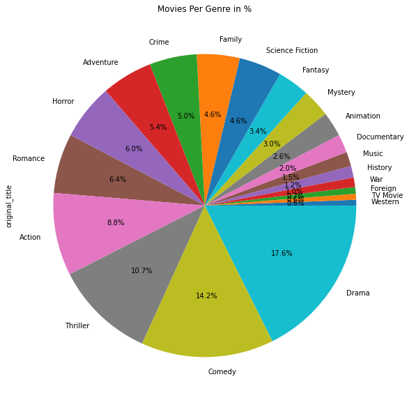

```python
genres_count['original_title'].plot.pie(title = 'Movies Per Genre in %', autopct = '%1.1f%%', figsize = (10,10))
```

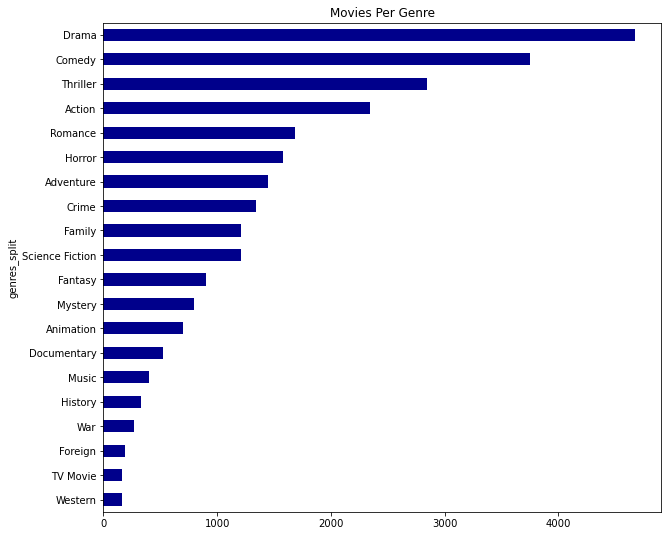

```python
genres_count['original_title'].plot.barh(title = 'Movies Per Genre', color = 'DarkBlue', figsize = (10,9))
```

1. Which genres have high average budget and revenue?

```python
genres_avg = movies_genre.groupby('genres_split').mean()
pd.options.display.float_format = '{:2f}'.format
genres_avg
```

| genres_split | popularity | budget | revenue | runtime | release_year | vote_count | vote_average | profit |
| --- | --- | --- | --- | --- | --- | --- | --- | --- |
| Action | 0.926274 | 27727820.331376 | 72794732.002517 | 104.917785 | 2000.056208 | 392.993708 | 5.787752 | 45066911.671141 |
| Adventure | 1.154259 | 37543694.530931 | 113137861.069341 | 106.173351 | 1999.388851 | 513.125085 | 5.940585 | 75594166.538409 |
| Animation | 0.852182 | 23159781.606581 | 75256062.223176 | 68.181688 | 2003.995708 | 303.000000 | 6.403147 | 52096280.616595 |
| Comedy | 0.592607 | 13297915.618244 | 37526242.072238 | 96.745057 | 2000.816240 | 176.436330 | 5.905167 | 24228326.453994 |
| Crime | 0.744930 | 17663801.124815 | 42368661.645495 | 106.917282 | 1999.491137 | 278.805022 | 6.124889 | 24704860.520679 |
| Documentary | 0.181432 | 577149.148077 | 2041106.994231 | 102.651923 | 2008.313462 | 35.105769 | 6.908462 | 1463957.846154 |
| Drama | 0.591495 | 11880717.773529 | 29232255.725840 | 110.478151 | 2000.929202 | 182.544538 | 6.165546 | 17351537.952311 |
| Family | 0.786668 | 23359337.420796 | 72433176.373680 | 89.603574 | 2000.774167 | 272.320877 | 5.997563 | 49073838.952884 |
| Fantasy | 0.992840 | 32612585.348253 | 96313657.081878 | 100.736900 | 2000.292576 | 420.741266 | 5.863537 | 63701071.733624 |
| Foreign | 0.191496 | 1451434.925532 | 1520459.835106 | 107.228723 | 2001.398936 | 16.627660 | 5.981383 | 69024.909574 |
| History | 0.575936 | 18594919.302395 | 32011793.215569 | 136.206587 | 1997.497006 | 183.772455 | 6.410479 | 13416873.913174 |
| Horror | 0.465357 | 6226529.210751 | 16822808.624313 | 94.424557 | 2001.117288 | 120.059866 | 5.337447 | 10596279.413561 |
| Music | 0.487321 | 9438627.549020 | 28571768.691176 | 105.137255 | 2000.196078 | 124.340686 | 6.480392 | 19133141.142157 |
| Mystery | 0.690012 | 16119270.062963 | 40217566.661728 | 105.928395 | 1999.850617 | 236.998765 | 5.946790 | 24098296.598765 |
| Romance | 0.592082 | 12531271.847547 | 35691972.327103 | 106.891355 | 2000.438668 | 166.070678 | 6.042874 | 23160700.479556 |
| Science Fiction | 1.001548 | 24972680.524003 | 70140558.034174 | 99.419854 | 1999.978845 | 437.096013 | 5.665582 | 45167877.510171 |
| TV Movie | 0.270896 | 267664.670659 | 251497.005988 | 91.982036 | 2004.634731 | 34.365269 | 5.788024 | -16167.664671 |
| Thriller | 0.741563 | 17207693.769178 | 41728417.543860 | 103.247678 | 2001.693498 | 255.484348 | 5.750671 | 24520723.774682 |
| War | 0.727683 | 20891886.103704 | 47605183.300000 | 127.625926 | 1996.096296 | 270.733333 | 6.297778 | 26713297.196296 |
| Western | 0.590615 | 18974107.975758 | 28568709.284848 | 117.575758 | 1986.915152 | 205.739394 | 6.083030 | 9594601.309091 |

```python
genres_avg.sort_values('revenue', ascending = True, inplace = True)
```

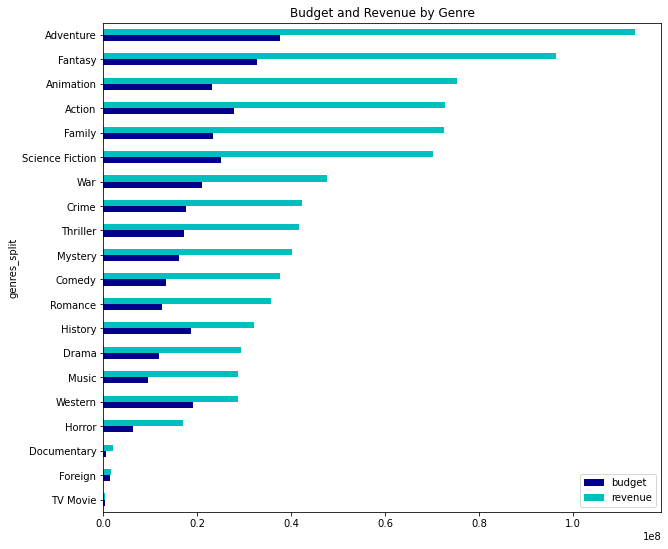

```python
genres_avg[['budget','revenue']].plot.barh(title = 'Budget and Revenue by Genre', color = ('DarkBlue','c'), figsize = (10,9))
```

1. Which genres have high average profit?

```python
genres_avg
```

| genres_split | popularity | budget | revenue | runtime | release_year | vote_count | vote_average | profit |
| --- | --- | --- | --- | --- | --- | --- | --- | --- |
| TV Movie | 0.270896 | 267664.670659 | 251497.005988 | 91.982036 | 2004.634731 | 34.365269 | 5.788024 | -16167.664671 |
| Foreign | 0.191496 | 1451434.925532 | 1520459.835106 | 107.228723 | 2001.398936 | 16.627660 | 5.981383 | 69024.909574 |
| Documentary | 0.181432 | 577149.148077 | 2041106.994231 | 102.651923 | 2008.313462 | 35.105769 | 6.908462 | 1463957.846154 |
| Horror | 0.465357 | 6226529.210751 | 16822808.624313 | 94.424557 | 2001.117288 | 120.059866 | 5.337447 | 10596279.413561 |
| Western | 0.590615 | 18974107.975758 | 28568709.284848 | 117.575758 | 1986.915152 | 205.739394 | 6.083030 | 9594601.309091 |
| Music | 0.487321 | 9438627.549020 | 28571768.691176 | 105.137255 | 2000.196078 | 124.340686 | 6.480392 | 19133141.142157 |
| Drama | 0.591495 | 11880717.773529 | 29232255.725840 | 110.478151 | 2000.929202 | 182.544538 | 6.165546 | 17351537.952311 |
| History | 0.575936 | 18594919.302395 | 32011793.215569 | 136.206587 | 1997.497006 | 183.772455 | 6.410479 | 13416873.913174 |
| Romance | 0.592082 | 12531271.847547 | 35691972.327103 | 106.891355 | 2000.438668 | 166.070678 | 6.042874 | 23160700.479556 |
| Comedy | 0.592607 | 13297915.618244 | 37526242.072238 | 96.745057 | 2000.816240 | 176.436330 | 5.905167 | 24228326.453994 |
| Mystery | 0.690012 | 16119270.062963 | 40217566.661728 | 105.928395 | 1999.850617 | 236.998765 | 5.946790 | 24098296.598765 |
| Thriller | 0.741563 | 17207693.769178 | 41728417.543860 | 103.247678 | 2001.693498 | 255.484348 | 5.750671 | 24520723.774682 |
| Crime | 0.744930 | 17663801.124815 | 42368661.645495 | 106.917282 | 1999.491137 | 278.805022 | 6.124889 | 24704860.520679 |
| War | 0.727683 | 20891886.103704 | 47605183.300000 | 127.625926 | 1996.096296 | 270.733333 | 6.297778 | 26713297.196296 |
| Science Fiction | 1.001548 | 24972680.524003 | 70140558.034174 | 99.419854 | 1999.978845 | 437.096013 | 5.665582 | 45167877.510171 |
| Family | 0.786668 | 23359337.420796 | 72433176.373680 | 89.603574 | 2000.774167 | 272.320877 | 5.997563 | 49073838.952884 |
| Action | 0.926274 | 27727820.331376 | 72794732.002517 | 104.917785 | 2000.056208 | 392.993708 | 5.787752 | 45066911.671141 |
| Animation | 0.852182 | 23159781.606581 | 75256062.223176 | 68.181688 | 2003.995708 | 303.000000 | 6.403147 | 52096280.616595 |
| Fantasy | 0.992840 | 32612585.348253 | 96313657.081878 | 100.736900 | 2000.292576 | 420.741266 | 5.863537 | 63701071.733624 |
| Adventure | 1.154259 | 37543694.530931 | 113137861.069341 | 106.173351 | 1999.388851 | 513.125085 | 5.940585 | 75594166.538409 |

```python
genres_avg.sort_values('profit', ascending = True, inplace = True)
```

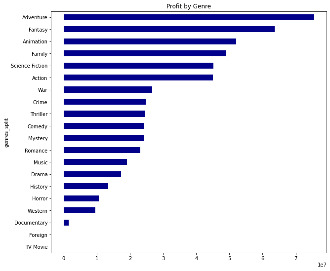

```python
genres_avg['profit'].plot.barh(title = 'Profit by Genre', color = 'DarkBlue', figsize = (10,9))
```

1. Which genres ahve high average popularity?

```python
movies.head()
```

|  | id | imdb_id | popularity | budget | revenue | original_title | cast | homepage | director | tagline | keywords | overview | runtime | genres | production_companies | release_date | vote_count | vote_average | release_year | budget_adj | revenue_adj | profit |
| --- | --- | --- | --- | --- | --- | --- | --- | --- | --- | --- | --- | --- | --- | --- | --- | --- | --- | --- | --- | --- | --- | --- |
| 0 | 135397 | tt0369610 | 32.985763 | 150000000 | 1513528810 | Jurassic World | Chris Pratt\|Bryce Dallas Howard\|Irrfan Khan\|Vi... | http://www.jurassicworld.com/ | Colin Trevorrow | The park is open. | monster\|dna\|tyrannosaurus rex\|velociraptor\|island | Twenty-two years after the events of Jurassic ... | 124 | Action\|Adventure\|Science Fiction\|Thriller | Universal Studios\|Amblin Entertainment\|Legenda... | 6/9/15 | 5562 | 6.500000 | 2015 | 137999939.280026 | 1392445892.523800 | 1363528810 |
| 1 | 76341 | tt1392190 | 28.419936 | 150000000 | 378436354 | Mad Max: Fury Road | Tom Hardy\|Charlize Theron\|Hugh Keays-Byrne\|Nic... | http://www.madmaxmovie.com/ | George Miller | What a Lovely Day. | future\|chase\|post-apocalyptic\|dystopia\|australia | An apocalyptic story set in the furthest reach... | 120 | Action\|Adventure\|Science Fiction\|Thriller | Village Roadshow Pictures\|Kennedy Miller Produ... | 5/13/15 | 6185 | 7.100000 | 2015 | 137999939.280026 | 348161292.489031 | 228436354 |
| 2 | 262500 | tt2908446 | 13.112507 | 110000000 | 295238201 | Insurgent | Shailene Woodley\|Theo James\|Kate Winslet\|Ansel... | http://www.thedivergentseries.movie/#insurgent | Robert Schwentke | One Choice Can Destroy You | based on novel\|revolution\|dystopia\|sequel\|dyst... | Beatrice Prior must confront her inner demons ... | 119 | Adventure\|Science Fiction\|Thriller | Summit Entertainment\|Mandeville Films\|Red Wago... | 3/18/15 | 2480 | 6.300000 | 2015 | 101199955.472019 | 271619025.407628 | 185238201 |
| 3 | 140607 | tt2488496 | 11.173104 | 200000000 | 2068178225 | Star Wars: The Force Awakens | Harrison Ford\|Mark Hamill\|Carrie Fisher\|Adam D... | http://www.starwars.com/films/star-wars-episod... | J.J. Abrams | Every generation has a story. | android\|spaceship\|jedi\|space opera\|3d | Thirty years after defeating the Galactic Empi... | 136 | Action\|Adventure\|Science Fiction\|Fantasy | Lucasfilm\|Truenorth Productions\|Bad Robot | 12/15/15 | 5292 | 7.500000 | 2015 | 183999919.040035 | 1902723129.801820 | 1868178225 |
| 4 | 168259 | tt2820852 | 9.335014 | 190000000 | 1506249360 | Furious 7 | Vin Diesel\|Paul Walker\|Jason Statham\|Michelle ... | http://www.furious7.com/ | James Wan | Vengeance Hits Home | car race\|speed\|revenge\|suspense\|car | Deckard Shaw seeks revenge against Dominic Tor... | 137 | Action\|Crime\|Thriller | Universal Pictures\|Original Film\|Media Rights ... | 4/1/15 | 2947 | 7.300000 | 2015 | 174799923.088033 | 1385748801.470520 | 1316249360 |

```python
genres_avg
```

| genres_split | popularity | budget | revenue | runtime | release_year | vote_count | vote_average | profit |
| --- | --- | --- | --- | --- | --- | --- | --- | --- |
| TV Movie | 0.270896 | 267664.670659 | 251497.005988 | 91.982036 | 2004.634731 | 34.365269 | 5.788024 | -16167.664671 |
| Foreign | 0.191496 | 1451434.925532 | 1520459.835106 | 107.228723 | 2001.398936 | 16.627660 | 5.981383 | 69024.909574 |
| Documentary | 0.181432 | 577149.148077 | 2041106.994231 | 102.651923 | 2008.313462 | 35.105769 | 6.908462 | 1463957.846154 |
| Western | 0.590615 | 18974107.975758 | 28568709.284848 | 117.575758 | 1986.915152 | 205.739394 | 6.083030 | 9594601.309091 |
| Horror | 0.465357 | 6226529.210751 | 16822808.624313 | 94.424557 | 2001.117288 | 120.059866 | 5.337447 | 10596279.413561 |
| History | 0.575936 | 18594919.302395 | 32011793.215569 | 136.206587 | 1997.497006 | 183.772455 | 6.410479 | 13416873.913174 |
| Drama | 0.591495 | 11880717.773529 | 29232255.725840 | 110.478151 | 2000.929202 | 182.544538 | 6.165546 | 17351537.952311 |
| Music | 0.487321 | 9438627.549020 | 28571768.691176 | 105.137255 | 2000.196078 | 124.340686 | 6.480392 | 19133141.142157 |
| Romance | 0.592082 | 12531271.847547 | 35691972.327103 | 106.891355 | 2000.438668 | 166.070678 | 6.042874 | 23160700.479556 |
| Mystery | 0.690012 | 16119270.062963 | 40217566.661728 | 105.928395 | 1999.850617 | 236.998765 | 5.946790 | 24098296.598765 |
| Comedy | 0.592607 | 13297915.618244 | 37526242.072238 | 96.745057 | 2000.816240 | 176.436330 | 5.905167 | 24228326.453994 |
| Thriller | 0.741563 | 17207693.769178 | 41728417.543860 | 103.247678 | 2001.693498 | 255.484348 | 5.750671 | 24520723.774682 |
| Crime | 0.744930 | 17663801.124815 | 42368661.645495 | 106.917282 | 1999.491137 | 278.805022 | 6.124889 | 24704860.520679 |
| War | 0.727683 | 20891886.103704 | 47605183.300000 | 127.625926 | 1996.096296 | 270.733333 | 6.297778 | 26713297.196296 |
| Action | 0.926274 | 27727820.331376 | 72794732.002517 | 104.917785 | 2000.056208 | 392.993708 | 5.787752 | 45066911.671141 |
| Science Fiction | 1.001548 | 24972680.524003 | 70140558.034174 | 99.419854 | 1999.978845 | 437.096013 | 5.665582 | 45167877.510171 |
| Family | 0.786668 | 23359337.420796 | 72433176.373680 | 89.603574 | 2000.774167 | 272.320877 | 5.997563 | 49073838.952884 |
| Animation | 0.852182 | 23159781.606581 | 75256062.223176 | 68.181688 | 2003.995708 | 303.000000 | 6.403147 | 52096280.616595 |
| Fantasy | 0.992840 | 32612585.348253 | 96313657.081878 | 100.736900 | 2000.292576 | 420.741266 | 5.863537 | 63701071.733624 |
| Adventure | 1.154259 | 37543694.530931 | 113137861.069341 | 106.173351 | 1999.388851 | 513.125085 | 5.940585 | 75594166.538409 |

```python
genres_avg.sort_values('popularity', ascending = True, inplace = True)
```

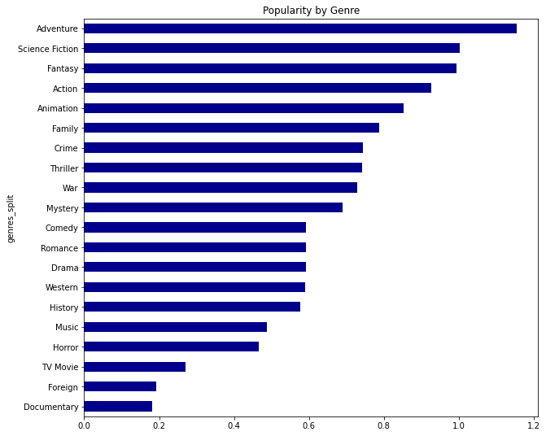

```python
genres_avg['popularity'].plot.barh(title = 'Popularity by Genre', color = 'DarkBlue', figsize = (10,9))
```

```python
movies_genre.head()
```

|  | popularity | budget | revenue | original_title | runtime | release_year | vote_count | vote_average | profit | genres_split |
| --- | --- | --- | --- | --- | --- | --- | --- | --- | --- | --- |
| 0 | 32.985763 | 150000000 | 1513528810 | Jurassic World | 124 | 2015 | 5562 | 6.500000 | 1363528810 | Action |
| 0 | 32.985763 | 150000000 | 1513528810 | Jurassic World | 124 | 2015 | 5562 | 6.500000 | 1363528810 | Adventure |
| 0 | 32.985763 | 150000000 | 1513528810 | Jurassic World | 124 | 2015 | 5562 | 6.500000 | 1363528810 | Science Fiction |
| 0 | 32.985763 | 150000000 | 1513528810 | Jurassic World | 124 | 2015 | 5562 | 6.500000 | 1363528810 | Thriller |
| 1 | 28.419936 | 150000000 | 378436354 | Mad Max: Fury Road | 120 | 2015 | 6185 | 7.100000 | 228436354 | Action |

```python
vote_fifty = movies_genre[(movies_genre['vote_count']>= 50) & (movies_genre['vote_average'] >= 8)]
vote_zero = movies_genre[movies_genre['vote_average'] >= 8]
```

```python
genres_vote = pd.DataFrame(vote_zero.groupby('genres_split').vote_average.nunique()).sort_values('vote_average',ascending = True)
```

```python
genres_vote
```

| genres_split | vote_average |
| --- | --- |
| Family | 1 |
| Action | 2 |
| Mystery | 2 |
| History | 2 |
| Fantasy | 2 |
| Adventure | 2 |
| War | 2 |
| Horror | 3 |
| Romance | 3 |
| Science Fiction | 3 |
| Thriller | 4 |
| Animation | 4 |
| Crime | 4 |
| Comedy | 5 |
| Drama | 6 |
| Music | 8 |
| Documentary | 9 |

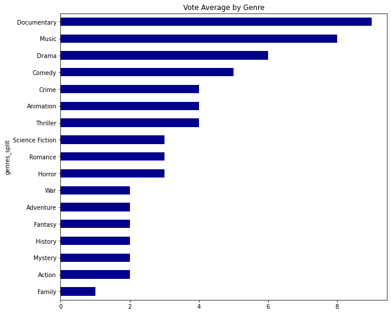

```python
genres_vote['vote_average'].plot.barh(title = 'Vote Average by Genre', color = 'DarkBlue', figsize = (10,9))
```

# Research Hypothesis:

1.The best movies according to vote average return high profit and revenue.

```python
movies.drop_duplicates(inplace = True)
movies['profit'] = movies['revenue'] - movies['budget']
movies_genre = movies[['popularity', 'budget', 'revenue', 'original_title', 'runtime', 'genres', 'release_date', 'vote_count', 'vote_average', 'profit']]
```

```python
movies_counted = movies_genre[movies_genre['vote_count'] >= 50]

movies_counted.corr(method = 'spearman')
```

|  | popularity | budget | revenue | runtime | vote_count | vote_average | profit |
| --- | --- | --- | --- | --- | --- | --- | --- |
| popularity | 1.000000 | 0.484952 | 0.588594 | 0.230214 | 0.768888 | 0.189226 | 0.498092 |
| budget | 0.484952 | 1.000000 | 0.714733 | 0.360001 | 0.554412 | -0.044050 | 0.334345 |
| revenue | 0.588594 | 0.714733 | 1.000000 | 0.341469 | 0.682550 | 0.112201 | 0.842278 |
| runtime | 0.230214 | 0.360001 | 0.341469 | 1.000000 | 0.263164 | 0.286082 | 0.211947 |
| vote_count | 0.768888 | 0.554412 | 0.682550 | 0.263164 | 1.000000 | 0.285084 | 0.583606 |
| vote_average | 0.189226 | -0.044050 | 0.112201 | 0.286082 | 0.285084 | 1.000000 | 0.198580 |
| profit | 0.498092 | 0.334345 | 0.842278 | 0.211947 | 0.583606 | 0.198580 | 1.000000 |

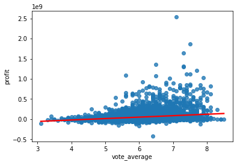

```python
import seaborn as  sns

sns.regplot(x = 'vote_average', y = 'profit', data = movies_counted, line_kws = {"color": 'red'})
```

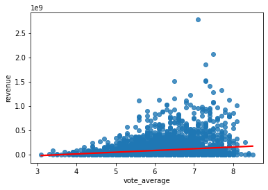

```python
sns.regplot(x = 'vote_average', y = 'revenue', data = movies_counted, line_kws = {"color": 'red'})
```

1. The best movies according to popularity return high profit and revenue.

```python
movies_counted.corr(method = 'spearman')
```

|  | popularity | budget | revenue | runtime | vote_count | vote_average | profit |
| --- | --- | --- | --- | --- | --- | --- | --- |
| popularity | 1.000000 | 0.484952 | 0.588594 | 0.230214 | 0.768888 | 0.189226 | 0.498092 |
| budget | 0.484952 | 1.000000 | 0.714733 | 0.360001 | 0.554412 | -0.044050 | 0.334345 |
| revenue | 0.588594 | 0.714733 | 1.000000 | 0.341469 | 0.682550 | 0.112201 | 0.842278 |
| runtime | 0.230214 | 0.360001 | 0.341469 | 1.000000 | 0.263164 | 0.286082 | 0.211947 |
| vote_count | 0.768888 | 0.554412 | 0.682550 | 0.263164 | 1.000000 | 0.285084 | 0.583606 |
| vote_average | 0.189226 | -0.044050 | 0.112201 | 0.286082 | 0.285084 | 1.000000 | 0.198580 |
| profit | 0.498092 | 0.334345 | 0.842278 | 0.211947 | 0.583606 | 0.198580 | 1.000000 |

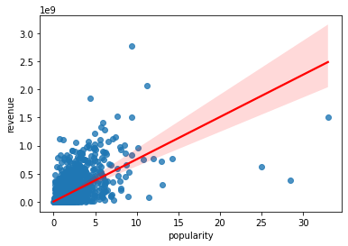

```python
import matplotlib.pyplot as plt
sns.regplot(x = 'popularity', y = 'revenue', data = movies_counted, line_kws = {"color": 'red'})
plt.figure(figsize = (10,20))
plt.show()
```

1. Highly budgeted movies return high revenue and profit.

```python
movies_counted.head()
```

|  | popularity | budget | revenue | original_title | runtime | genres | release_date | vote_count | vote_average | profit |
| --- | --- | --- | --- | --- | --- | --- | --- | --- | --- | --- |
| 0 | 32.985763 | 150000000 | 1513528810 | Jurassic World | 124 | Action\|Adventure\|Science Fiction\|Thriller | 6/9/15 | 5562 | 6.500000 | 1363528810 |
| 1 | 28.419936 | 150000000 | 378436354 | Mad Max: Fury Road | 120 | Action\|Adventure\|Science Fiction\|Thriller | 5/13/15 | 6185 | 7.100000 | 228436354 |
| 2 | 13.112507 | 110000000 | 295238201 | Insurgent | 119 | Adventure\|Science Fiction\|Thriller | 3/18/15 | 2480 | 6.300000 | 185238201 |
| 3 | 11.173104 | 200000000 | 2068178225 | Star Wars: The Force Awakens | 136 | Action\|Adventure\|Science Fiction\|Fantasy | 12/15/15 | 5292 | 7.500000 | 1868178225 |
| 4 | 9.335014 | 190000000 | 1506249360 | Furious 7 | 137 | Action\|Crime\|Thriller | 4/1/15 | 2947 | 7.300000 | 1316249360 |

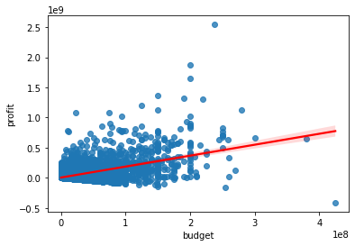

```python
sns.regplot(x = 'budget', y = 'profit', data = movies_counted, line_kws = {"color": 'red'})
plt.figure(figsize = (10,20))
plt.show()
```

1. Highly budgeted movies have a high popularity.

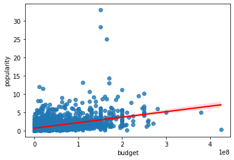

```python
sns.regplot(x = 'budget', y = 'popularity', data = movies_counted, line_kws = {"color": 'red'})
plt.figure(figsize = (10,20))
plt.show()
```

1. Look at Porfit Per Genre Per Year

```python
movies_genre.head()
```

[output not shown]

```python
time_genre = pd.DataFrame(movies_genre.groupby(['release_year', 'genres_split'])['profit'].mean())
```

```python
final_genre = pd.pivot_table(time_genre, values = 'profit', index = ['genres_split'], columns = ['release_year'])
```

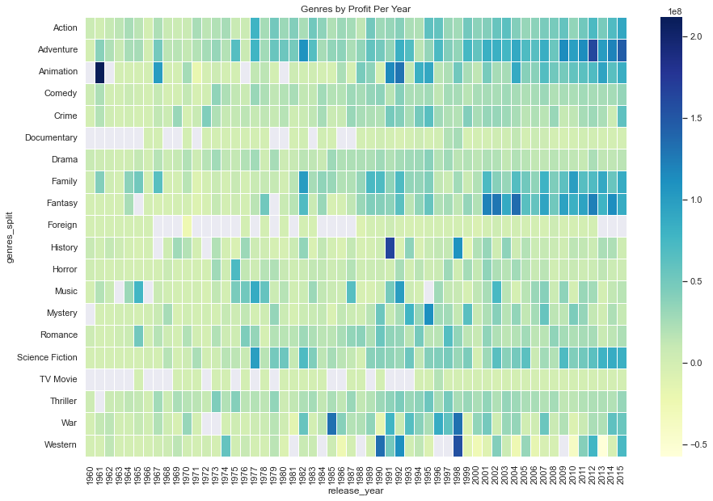

```python
sns.set(rc = {'figure.figsize':(15,10)})
sns.heatmap(final_genre, cmap = 'YlGnBu', linewidths = .5)
plt.title('Genres by Profit Per Year')
```

Using this heatmap we can see that movies of the following genre: Adventure, Fantasy, and Family started being famous in late 90s. Also, in 2010 and after, science fiction movies started having more importance than before. Another thing teh greyish places do represent the lack of data.